# Project: Investigate NICS Firearm Background Checks with FBI Gun Data and Census Data

- Introduction
- Data Wrangling
- Exploratory Data Analysis
- Conclusions

## Introduction

The data comes from the [FBI's National Instant Criminal Background Check System](https://www.fbi.gov/services/cjis/nics). The NICS is used by to determine whether a prospective buyer is eligible to buy firearms or explosives. Gun shops call into this system to ensure that each customer does not have a criminal record or isn't otherwise ineligible to make a purchase.

> Mandated by the Brady Handgun Violence Prevention Act of 1993 and launched by the FBI on November 30, 1998, NICS is used by Federal Firearms Licensees (FFLs) to instantly determine whether a prospective buyer is eligible to buy firearms or explosives. Before ringing up the sale, cashiers call in a check to the FBI or to other designated agencies to ensure that each customer does not have a criminal record or isn’t otherwise ineligible to make a purchase. More than 100 million such checks have been made in the last decade, leading to more than 700,000 denials.

### Notes on the NICS data

> The NICS data is found in one sheet of an **.xlsx** file. It contains the number of firearm checks by month, state, and type.

> **A one-to-one correlation cannot be made between a firearm background check and a firearm sale.**
> - These statistics represent the number of firearm background checks initiated through the NICS They do not represent the number of firearms sold.

> **Despite some vagaries, the FBI's NICS numbers are widely accepted as the best proxy for total gun sales in a given time period.**
> - As seen in the late February-early March 2014 bubble, many checks are for concealed carry permits, not actual gun sales. Kentucky runs a new check on each concealed carry license holder each month. And of course, the FBI's numbers don't include private gun sales, many of which do not require a background check. A forthcoming study conducted by Harvard researchers found that roughly 40 percent of respondents had acquired their most recent firearm without going through a background check.

> **Because state laws differ, sales levels between states cannot be directly compared.**
> - Sales estimates are calculated from handgun, long gun and multiple-gun background checks. Permit checks and other categories of background checks are excluded. In California, multiple-gun checks were excluded because data was inconsistent.

> **Multipliers on background checks are estimated to project the sales.**
> - To convert background checks into estimated sales, we relied on a method suggested in the Small Arms Survey by Jurgen Brauer, a professor at Georgia Regents University. Each long gun and handgun check was counted as 1.1 sales. Each multiple-gun check was counted as two sales. Permit checks and other types of checks were omitted. The multiplier is an estimate based on Mr. Brauer's interviews with gun shop owners.

Original notes and caveats can be found on [Github](https://github.com/BuzzFeedNews/nics-firearm-background-checks/blob/master/README.md).

### Notes on the census data

> The NICS data has been supplemented with state level census data from [census.gov](https://www.census.gov/).
> - The U.S. census data is found in a **.csv** file. It contains several variables at the state level. Most variables just have one data point per state (2016), but a few have data for more than one year.

In this project, I'll first load, check and clean the dataset, and then explore there questions.

- **What census data is most associated with high gun check per capita?**
- **Which states have had the highest growth in gun checks?**
- **What is the overall trend of gun checks?**

In the end, conclusions will be drawn.

```python
# import statements for all of the packages and the magic commands
import numpy as np
import pandas as pd
import matplotlib.pyplot as plt
import seaborn as sns
%matplotlib inline
```

## Data Wrangling

### General Properties

```python
# Load data
df_gun = pd.read_excel('gun-data.xlsx',sheet_name='Sheet1')
df_census = pd.read_csv('u.s.-census-data.csv')
```

```python
# print out a few lines.
df_gun.head(3)
```

|  | month | state | permit | permit_recheck | handgun | long_gun | other | multiple | admin | prepawn_handgun | ... | returned_other | rentals_handgun | rentals_long_gun | private_sale_handgun | private_sale_long_gun | private_sale_other | return_to_seller_handgun | return_to_seller_long_gun | return_to_seller_other | totals |
| --- | --- | --- | --- | --- | --- | --- | --- | --- | --- | --- | --- | --- | --- | --- | --- | --- | --- | --- | --- | --- | --- |
| 0 | 2017-09 | Alabama | 16717.0 | 0.0 | 5734.0 | 6320.0 | 221.0 | 317 | 0.0 | 15.0 | ... | 0.0 | 0.0 | 0.0 | 9.0 | 16.0 | 3.0 | 0.0 | 0.0 | 3.0 | 32019 |
| 1 | 2017-09 | Alaska | 209.0 | 2.0 | 2320.0 | 2930.0 | 219.0 | 160 | 0.0 | 5.0 | ... | 0.0 | 0.0 | 0.0 | 17.0 | 24.0 | 1.0 | 0.0 | 0.0 | 0.0 | 6303 |
| 2 | 2017-09 | Arizona | 5069.0 | 382.0 | 11063.0 | 7946.0 | 920.0 | 631 | 0.0 | 13.0 | ... | 0.0 | 0.0 | 0.0 | 38.0 | 12.0 | 2.0 | 0.0 | 0.0 | 0.0 | 28394 |

3 rows × 27 columns

```python
# Perform operations to inspect data types and look for instances of missing or possibly errant data.
df_gun.info()
```

```
<class 'pandas.core.frame.DataFrame'>
RangeIndex: 12485 entries, 0 to 12484
Data columns (total 27 columns):
month                        12485 non-null object
state                        12485 non-null object
permit                       12461 non-null float64
permit_recheck               1100 non-null float64
handgun                      12465 non-null float64
long_gun                     12466 non-null float64
other                        5500 non-null float64
multiple                     12485 non-null int64
admin                        12462 non-null float64
prepawn_handgun              10542 non-null float64
prepawn_long_gun             10540 non-null float64
prepawn_other                5115 non-null float64
redemption_handgun           10545 non-null float64
redemption_long_gun          10544 non-null float64
redemption_other             5115 non-null float64
returned_handgun             2200 non-null float64
returned_long_gun            2145 non-null float64
returned_other               1815 non-null float64
rentals_handgun              990 non-null float64
rentals_long_gun             825 non-null float64
private_sale_handgun         2750 non-null float64
private_sale_long_gun        2750 non-null float64
private_sale_other           2750 non-null float64
return_to_seller_handgun     2475 non-null float64
return_to_seller_long_gun    2750 non-null float64
return_to_seller_other       2255 non-null float64
totals                       12485 non-null int64
dtypes: float64(23), int64(2), object(2)
memory usage: 2.6+ MB
```

Several columns have missing data.

```python
df_gun.duplicated().sum()
```

```
0
```

There is no duplicated row.

```python
df_gun.month.unique()
```

```
array(['2017-09', '2017-08', '2017-07', '2017-06', '2017-05', '2017-04',
       '2017-03', '2017-02', '2017-01', '2016-12', '2016-11', '2016-10',
       '2016-09', '2016-08', '2016-07', '2016-06', '2016-05', '2016-04',
       '2016-03', '2016-02', '2016-01', '2015-12', '2015-11', '2015-10',
       '2015-09', '2015-08', '2015-07', '2015-06', '2015-05', '2015-04',
       '2015-03', '2015-02', '2015-01', '2014-12', '2014-11', '2014-10',
       '2014-09', '2014-08', '2014-07', '2014-06', '2014-05', '2014-04',
       '2014-03', '2014-02', '2014-01', '2013-12', '2013-11', '2013-10',
       '2013-09', '2013-08', '2013-07', '2013-06', '2013-05', '2013-04',
       '2013-03', '2013-02', '2013-01', '2012-12', '2012-11', '2012-10',
       '2012-09', '2012-08', '2012-07', '2012-06', '2012-05', '2012-04',
       '2012-03', '2012-02', '2012-01', '2011-12', '2011-11', '2011-10',
       '2011-09', '2011-08', '2011-07', '2011-06', '2011-05', '2011-04',
       '2011-03', '2011-02', '2011-01', '2010-12', '2010-11', '2010-10',
       '2010-09', '2010-08', '2010-07', '2010-06', '2010-05', '2010-04',
       '2010-03', '2010-02', '2010-01', '2009-12', '2009-11', '2009-10',
       '2009-09', '2009-08', '2009-07', '2009-06', '2009-05', '2009-04',
       '2009-03', '2009-02', '2009-01', '2008-12', '2008-11', '2008-10',
       '2008-09', '2008-08', '2008-07', '2008-06', '2008-05', '2008-04',
       '2008-03', '2008-02', '2008-01', '2007-12', '2007-11', '2007-10',
       '2007-09', '2007-08', '2007-07', '2007-06', '2007-05', '2007-04',
       '2007-03', '2007-02', '2007-01', '2006-12', '2006-11', '2006-10',
       '2006-09', '2006-08', '2006-07', '2006-06', '2006-05', '2006-04',
       '2006-03', '2006-02', '2006-01', '2005-12', '2005-11', '2005-10',
       '2005-09', '2005-08', '2005-07', '2005-06', '2005-05', '2005-04',
       '2005-03', '2005-02', '2005-01', '2004-12', '2004-11', '2004-10',
       '2004-09', '2004-08', '2004-07', '2004-06', '2004-05', '2004-04',
       '2004-03', '2004-02', '2004-01', '2003-12', '2003-11', '2003-10',
       '2003-09', '2003-08', '2003-07', '2003-06', '2003-05', '2003-04',
       '2003-03', '2003-02', '2003-01', '2002-12', '2002-11', '2002-10',
       '2002-09', '2002-08', '2002-07', '2002-06', '2002-05', '2002-04',
       '2002-03', '2002-02', '2002-01', '2001-12', '2001-11', '2001-10',
       '2001-09', '2001-08', '2001-07', '2001-06', '2001-05', '2001-04',
       '2001-03', '2001-02', '2001-01', '2000-12', '2000-11', '2000-10',
       '2000-09', '2000-08', '2000-07', '2000-06', '2000-05', '2000-04',
       '2000-03', '2000-02', '2000-01', '1999-12', '1999-11', '1999-10',
       '1999-09', '1999-08', '1999-07', '1999-06', '1999-05', '1999-04',
       '1999-03', '1999-02', '1999-01', '1998-12', '1998-11'],
      dtype=object)
```

The data range is 227 months, from 1998-11 to 2017-09, only 9 months in 2017. Mandated gun check Act was launched on 1998-11.

```python
df_gun.describe()
```

|  | permit | permit_recheck | handgun | long_gun | other | multiple | admin | prepawn_handgun | prepawn_long_gun | prepawn_other | ... | returned_other | rentals_handgun | rentals_long_gun | private_sale_handgun | private_sale_long_gun | private_sale_other | return_to_seller_handgun | return_to_seller_long_gun | return_to_seller_other | totals |
| --- | --- | --- | --- | --- | --- | --- | --- | --- | --- | --- | --- | --- | --- | --- | --- | --- | --- | --- | --- | --- | --- |
| count | 12461.000000 | 1100.000000 | 12465.000000 | 12466.000000 | 5500.000000 | 12485.000000 | 12462.000000 | 10542.000000 | 10540.000000 | 5115.000000 | ... | 1815.000000 | 990.000000 | 825.000000 | 2750.000000 | 2750.000000 | 2750.000000 | 2475.000000 | 2750.000000 | 2255.000000 | 12485.000000 |
| mean | 6413.629404 | 1165.956364 | 5940.881107 | 7810.847585 | 360.471636 | 268.603364 | 58.898090 | 4.828021 | 7.834156 | 0.165591 | ... | 1.027548 | 0.076768 | 0.087273 | 14.936000 | 11.602909 | 1.030182 | 0.402020 | 0.441818 | 0.105987 | 21595.725911 |
| std | 23752.338269 | 9224.200609 | 8618.584060 | 9309.846140 | 1349.478273 | 783.185073 | 604.814818 | 10.907756 | 16.468028 | 1.057105 | ... | 4.386296 | 0.634503 | 0.671649 | 71.216021 | 54.253090 | 4.467843 | 1.446568 | 1.528223 | 0.427363 | 32591.418387 |
| min | 0.000000 | 0.000000 | 0.000000 | 0.000000 | 0.000000 | 0.000000 | 0.000000 | 0.000000 | 0.000000 | 0.000000 | ... | 0.000000 | 0.000000 | 0.000000 | 0.000000 | 0.000000 | 0.000000 | 0.000000 | 0.000000 | 0.000000 | 0.000000 |
| 25% | 0.000000 | 0.000000 | 865.000000 | 2078.250000 | 17.000000 | 15.000000 | 0.000000 | 0.000000 | 0.000000 | 0.000000 | ... | 0.000000 | 0.000000 | 0.000000 | 0.000000 | 0.000000 | 0.000000 | 0.000000 | 0.000000 | 0.000000 | 4638.000000 |
| 50% | 518.000000 | 0.000000 | 3059.000000 | 5122.000000 | 121.000000 | 125.000000 | 0.000000 | 0.000000 | 1.000000 | 0.000000 | ... | 0.000000 | 0.000000 | 0.000000 | 0.000000 | 0.000000 | 0.000000 | 0.000000 | 0.000000 | 0.000000 | 12399.000000 |
| 75% | 4272.000000 | 0.000000 | 7280.000000 | 10380.750000 | 354.000000 | 301.000000 | 0.000000 | 5.000000 | 8.000000 | 0.000000 | ... | 0.000000 | 0.000000 | 0.000000 | 2.000000 | 4.000000 | 0.000000 | 0.000000 | 0.000000 | 0.000000 | 25453.000000 |
| max | 522188.000000 | 116681.000000 | 107224.000000 | 108058.000000 | 77929.000000 | 38907.000000 | 28083.000000 | 164.000000 | 269.000000 | 49.000000 | ... | 64.000000 | 12.000000 | 12.000000 | 1017.000000 | 777.000000 | 71.000000 | 28.000000 | 17.000000 | 4.000000 | 541978.000000 |

8 rows × 25 columns

```python
df_gun['state'].nunique()
```

```
55
```

There are 55 states in the gun data, including some territories.

```python
df_census.head(3)
```

|  | Fact | Fact Note | Alabama | Alaska | Arizona | Arkansas | California | Colorado | Connecticut | Delaware | ... | South Dakota | Tennessee | Texas | Utah | Vermont | Virginia | Washington | West Virginia | Wisconsin | Wyoming |
| --- | --- | --- | --- | --- | --- | --- | --- | --- | --- | --- | --- | --- | --- | --- | --- | --- | --- | --- | --- | --- | --- |
| 0 | Population estimates, July 1, 2016, (V2016) | NaN | 4,863,300 | 741,894 | 6,931,071 | 2,988,248 | 39,250,017 | 5,540,545 | 3,576,452 | 952,065 | ... | 865454 | 6651194 | 27,862,596 | 3,051,217 | 624,594 | 8,411,808 | 7,288,000 | 1,831,102 | 5,778,708 | 585,501 |
| 1 | Population estimates base, April 1, 2010, (V2... | NaN | 4,780,131 | 710,249 | 6,392,301 | 2,916,025 | 37,254,522 | 5,029,324 | 3,574,114 | 897,936 | ... | 814195 | 6346298 | 25,146,100 | 2,763,888 | 625,741 | 8,001,041 | 6,724,545 | 1,853,011 | 5,687,289 | 563,767 |
| 2 | Population, percent change - April 1, 2010 (es... | NaN | 1.70% | 4.50% | 8.40% | 2.50% | 5.40% | 10.20% | 0.10% | 6.00% | ... | 0.063 | 0.048 | 10.80% | 10.40% | -0.20% | 5.10% | 8.40% | -1.20% | 1.60% | 3.90% |

3 rows × 52 columns

```python
df_census.info()
```

```
<class 'pandas.core.frame.DataFrame'>
RangeIndex: 85 entries, 0 to 84
Data columns (total 52 columns):
Fact              80 non-null object
Fact Note         28 non-null object
Alabama           65 non-null object
Alaska            65 non-null object
Arizona           65 non-null object
Arkansas          65 non-null object
California        65 non-null object
Colorado          65 non-null object
Connecticut       65 non-null object
Delaware          65 non-null object
Florida           65 non-null object
Georgia           65 non-null object
Hawaii            65 non-null object
Idaho             65 non-null object
Illinois          65 non-null object
Indiana           65 non-null object
Iowa              65 non-null object
Kansas            65 non-null object
Kentucky          65 non-null object
Louisiana         65 non-null object
Maine             65 non-null object
Maryland          65 non-null object
Massachusetts     65 non-null object
Michigan          65 non-null object
Minnesota         65 non-null object
Mississippi       65 non-null object
Missouri          65 non-null object
Montana           65 non-null object
Nebraska          65 non-null object
Nevada            65 non-null object
New Hampshire     65 non-null object
New Jersey        65 non-null object
New Mexico        65 non-null object
New York          65 non-null object
North Carolina    65 non-null object
North Dakota      65 non-null object
Ohio              65 non-null object
Oklahoma          65 non-null object
Oregon            65 non-null object
Pennsylvania      65 non-null object
Rhode Island      65 non-null object
South Carolina    65 non-null object
South Dakota      65 non-null object
Tennessee         65 non-null object
Texas             65 non-null object
Utah              65 non-null object
Vermont           65 non-null object
Virginia          65 non-null object
Washington        65 non-null object
West Virginia     65 non-null object
Wisconsin         65 non-null object
Wyoming           65 non-null object
dtypes: object(52)
memory usage: 34.6+ KB
```

All the data are str types.

```python
df_census.Fact
```

```
0          Population estimates, July 1, 2016,  (V2016)
1     Population estimates base, April 1, 2010,  (V2...
2     Population, percent change - April 1, 2010 (es...
3                     Population, Census, April 1, 2010
4     Persons under 5 years, percent, July 1, 2016, ...
5         Persons under 5 years, percent, April 1, 2010
6     Persons under 18 years, percent, July 1, 2016,...
7        Persons under 18 years, percent, April 1, 2010
8     Persons 65 years and over, percent,  July 1, 2...
9     Persons 65 years and over, percent, April 1, 2010
10     Female persons, percent,  July 1, 2016,  (V2016)
11               Female persons, percent, April 1, 2010
12         White alone, percent, July 1, 2016,  (V2016)
13    Black or African American alone, percent, July...
14    American Indian and Alaska Native alone, perce...
```

[output cut: 47 more lines]

The census data has many explanatory strings rows to be clean.

```python
df_census[df_census['Fact Note'].notnull()].loc[:,['Fact','Fact Note']]
```

|  | Fact | Fact Note |
| --- | --- | --- |
| 12 | White alone, percent, July 1, 2016, (V2016) | (a) |
| 13 | Black or African American alone, percent, July... | (a) |
| 14 | American Indian and Alaska Native alone, perce... | (a) |
| 15 | Asian alone, percent, July 1, 2016, (V2016) | (a) |
| 16 | Native Hawaiian and Other Pacific Islander alo... | (a) |
| 18 | Hispanic or Latino, percent, July 1, 2016, (V... | (b) |
| 40 | Total accommodation and food services sales, 2... | (c) |
| 41 | Total health care and social assistance receip... | (c) |
| 42 | Total manufacturers shipments, 2012 ($1,000) | (c) |
| 43 | Total merchant wholesaler sales, 2012 ($1,000) | (c) |
| 44 | Total retail sales, 2012 ($1,000) | (c) |
| 45 | Total retail sales per capita, 2012 | (c) |
| 50 | Total employer establishments, 2015 | Includes data not distributed by county. |
| 51 | Total employment, 2015 | Includes data not distributed by county. |
| 52 | Total annual payroll, 2015 ($1,000) | Includes data not distributed by county. |
| 53 | Total employment, percent change, 2014-2015 | Includes data not distributed by county. |
| 69 | 1 | Includes data not distributed by county. |
| 72 | (a) | Includes persons reporting only one race |
| 73 | (b) | Hispanics may be of any race, so also are incl... |
| 74 | (c) | Economic Census - Puerto Rico data are not com... |
| 77 | - | Either no or too few sample observations were ... |
| 78 | D | Suppressed to avoid disclosure of confidential... |
| 79 | F | Fewer than 25 firms |
| 80 | FN | Footnote on this item in place of data |
| 81 | NaN | Not available |
| 82 | S | Suppressed; does not meet publication standards |
| 83 | X | Not applicable |
| 84 | Z | Value greater than zero but less than half uni... |

The Fact Note column give notes marks.

```python
(df_gun.iloc[:,2:-1].sum(1) != df_gun['totals']).sum()
```

```
0
```

The totals column is equals to the sum of categorical gun check columns, so in next cell, fill all the missing data with 0 is reasonable.

```python
df_gun.fillna(0,inplace=True)
```

```python
df_gun.iloc[:,2:] = df_gun.iloc[:,2:].astype(int)
```

Convert background check data to integer.

```python
df_gun['year'] = df_gun['month'].str[0:4]
```

Add 'year' column for annual analysis

```python
df_census.drop(df_census.index[65:len(df_census)],inplace=True)
```

Drop the explanatory rows in df_census.

```python
df_census_2016 = df_census[df_census['Fact'].str.contains('2016')]
df_census_2016.Fact
df_census_2016 = df_census_2016.drop('Fact Note',axis=1)
```

```python
dropind = df_census_2016[df_census_2016['Fact'].str.contains('2010')].index
df_census_2016 = df_census_2016.drop(dropind)
```

Only keep census data of 2016 and drop 'Fact Note', which has no influence on later analysis.

```python
df_census_2016.reset_index(drop=True,inplace=True)
```

```python
statecol = df_census_2016.columns[1:len(df_census_2016.columns)]
statecol.shape
```

```
(50,)
```

The census data has only 50 states. Recall that gun data has 55 states. The two dataframe need to be merge.

```python
df_census_2016=df_census_2016.apply(lambda x: x.str.replace(',', ''), axis=1)
```

To deal with the ',' in the cnesus data, such as 'population' etc.

```python
df1 = df_census_2016[statecol].apply(lambda x: x.str.findall('[a-zA-Z]'), axis=1)
df_census_2016[df1.any().index[df1.any()]]
```

|  | Maine | Michigan | Vermont | West Virginia |
| --- | --- | --- | --- | --- |
| 0 | 1331479 | 9928300 | 624594 | 1831102 |
| 1 | 4.90% | 5.80% | 4.90% | 5.50% |
| 2 | 19.10% | 22.10% | 19.00% | 20.50% |
| 3 | 19.40% | 16.20% | 18.10% | 18.80% |
| 4 | 51.00% | 50.80% | 50.60% | 50.50% |
| 5 | 94.80% | 79.60% | 94.60% | 93.60% |
| 6 | 1.50% | 14.20% | 1.30% | 3.60% |
| 7 | 0.70% | 0.70% | 0.40% | 0.20% |
| 8 | 1.20% | 3.10% | 1.80% | 0.80% |
| 9 | Z | Z | Z | Z |
| 10 | 1.70% | 2.40% | 1.90% | 1.70% |
| 11 | 1.60% | 5.00% | 1.90% | 1.50% |
| 12 | 93.50% | 75.40% | 93.10% | 92.30% |
| 13 | 730705 | 4560055 | 329525 | 886640 |
| 14 | 4010 | 20408 | 1771 | 2544 |

Find out any letter word in the data, the results show 'Z' in some columns.

```python
df_census_2016[statecol] = df_census_2016[statecol].apply(lambda x: x.str.replace('Z', '0'), axis=1).copy()
```

Since 'Z' means Value greater than zero but less than half unit of measure shown, replace it with 0.

```python
df_census_2016.head(3)
```

|  | Fact | Alabama | Alaska | Arizona | Arkansas | California | Colorado | Connecticut | Delaware | Florida | ... | South Dakota | Tennessee | Texas | Utah | Vermont | Virginia | Washington | West Virginia | Wisconsin | Wyoming |
| --- | --- | --- | --- | --- | --- | --- | --- | --- | --- | --- | --- | --- | --- | --- | --- | --- | --- | --- | --- | --- | --- |
| 0 | Population estimates July 1 2016 (V2016) | 4863300 | 741894 | 6931071 | 2988248 | 39250017 | 5540545 | 3576452 | 952065 | 20612439 | ... | 865454 | 6651194 | 27862596 | 3051217 | 624594 | 8411808 | 7288000 | 1831102 | 5778708 | 585501 |
| 1 | Persons under 5 years percent July 1 2016 (V2... | 6.00% | 7.30% | 6.30% | 6.40% | 6.30% | 6.10% | 5.20% | 5.80% | 5.50% | ... | 0.071 | 0.061 | 7.20% | 8.30% | 4.90% | 6.10% | 6.20% | 5.50% | 5.80% | 6.50% |
| 2 | Persons under 18 years percent July 1 2016 (V... | 22.60% | 25.20% | 23.50% | 23.60% | 23.20% | 22.80% | 21.10% | 21.50% | 20.10% | ... | 0.246 | 0.226 | 26.20% | 30.20% | 19.00% | 22.20% | 22.40% | 20.50% | 22.30% | 23.70% |

3 rows × 51 columns

Now only '%' needs to be dealt with.

```python
df_census_2016['Fact'] = df_census_2016['Fact'].str.replace(" ", "_")
df_census_2016['Fact'] = df_census_2016['Fact'].str.replace("_July_1_2016__\(V2016\)","")
df_census_2016['Fact'] = df_census_2016['Fact'].str.replace("_alone","")
df_census_2016['Fact'] = df_census_2016['Fact'].str.replace("percent","pt")
df_census_2016['Fact'] = df_census_2016['Fact'].str.replace("_pt_","_pt")
df_census_2016['Fact'] = df_census_2016['Fact'].str.replace("units_","units")
df_census_2016['Fact'] = df_census_2016['Fact'].str.replace("_2016","")
df_census_2016['Fact']
```

```
0                              Population_estimates
1                          Persons_under_5_years_pt
2                         Persons_under_18_years_pt
3                      Persons_65_years_and_over_pt
4                                 Female_persons_pt
5                                          White_pt
6                      Black_or_African_American_pt
7              American_Indian_and_Alaska_Native_pt
8                                          Asian_pt
9     Native_Hawaiian_and_Other_Pacific_Islander_pt
10                             Two_or_More_Races_pt
11                            Hispanic_or_Latino_pt
12                  White_not_Hispanic_or_Latino_pt
13                                    Housing_units
14                                 Building_permits
Name: Fact, dtype: object
```

Change 'Fact' column to a more concise and clear way.

```python
df_notpercent1 = df_census_2016[~df_census_2016['Fact'].str.contains('pt')]
mask = np.column_stack([df_census_2016[col].str.contains('%', na=False) for col in df_census_2016])
df_notpercent2 = df_census_2016.loc[:,~mask.any(axis=0)]
```

df_notpercent1 saves those rows of non-percentage census, such as 'Population','Housing unit' etc.

Since we observe that the percentage census data have mixed type for differenet states, df_notpercent2 saves those float string data in percentage census, such as 'South Dakota' etc.

```python
df_census_2016[statecol]= df_census_2016[statecol].apply(lambda x: x.str.strip('%').astype(float)/100,axis=1).copy()
```

Convert the data with '%' to float type.

```python
df_census_2016.update(df_notpercent1)
df_census_2016.update(df_notpercent2)
```

Update the df_census_2016 with previous saved dataframes to avoid '/100' operation in the last cell.

```python
df_census_2016[statecol] = df_census_2016[statecol].astype(float)
```

Convert data of states to float type.

```python
df_census_2016.head(3)
```

|  | Fact | Alabama | Alaska | Arizona | Arkansas | California | Colorado | Connecticut | Delaware | Florida | ... | South Dakota | Tennessee | Texas | Utah | Vermont | Virginia | Washington | West Virginia | Wisconsin | Wyoming |
| --- | --- | --- | --- | --- | --- | --- | --- | --- | --- | --- | --- | --- | --- | --- | --- | --- | --- | --- | --- | --- | --- |
| 0 | Population_estimates | 4863300.000 | 741894.000 | 6931071.000 | 2988248.000 | 3.925002e+07 | 5540545.000 | 3576452.000 | 952065.000 | 2.061244e+07 | ... | 865454.000 | 6651194.000 | 2.786260e+07 | 3051217.000 | 624594.000 | 8411808.000 | 7288000.000 | 1831102.000 | 5778708.000 | 585501.000 |
| 1 | Persons_under_5_years_pt | 0.060 | 0.073 | 0.063 | 0.064 | 6.300000e-02 | 0.061 | 0.052 | 0.058 | 5.500000e-02 | ... | 0.071 | 0.061 | 7.200000e-02 | 0.083 | 0.049 | 0.061 | 0.062 | 0.055 | 0.058 | 0.065 |
| 2 | Persons_under_18_years_pt | 0.226 | 0.252 | 0.235 | 0.236 | 2.320000e-01 | 0.228 | 0.211 | 0.215 | 2.010000e-01 | ... | 0.246 | 0.226 | 2.620000e-01 | 0.302 | 0.190 | 0.222 | 0.224 | 0.205 | 0.223 | 0.237 |

3 rows × 51 columns

```python
df_census_2016 = df_census_2016.T
df_census_2016.rename(columns=df_census_2016.iloc[0],inplace=True)
df_census_2016.drop(df_census_2016.index[0],inplace=True)
df_census_2016 = df_census_2016.infer_objects()
df_census_2016.head(3)
```

|  | Population_estimates | Persons_under_5_years_pt | Persons_under_18_years_pt | Persons_65_years_and_over_pt | Female_persons_pt | White_pt | Black_or_African_American_pt | American_Indian_and_Alaska_Native_pt | Asian_pt | Native_Hawaiian_and_Other_Pacific_Islander_pt | Two_or_More_Races_pt | Hispanic_or_Latino_pt | White_not_Hispanic_or_Latino_pt | Housing_units | Building_permits |
| --- | --- | --- | --- | --- | --- | --- | --- | --- | --- | --- | --- | --- | --- | --- | --- |
| Alabama | 4863300.0 | 0.060 | 0.226 | 0.161 | 0.516 | 0.693 | 0.268 | 0.007 | 0.014 | 0.001 | 0.016 | 0.042 | 0.658 | 2230185.0 | 15001.0 |
| Alaska | 741894.0 | 0.073 | 0.252 | 0.104 | 0.477 | 0.661 | 0.038 | 0.152 | 0.063 | 0.013 | 0.073 | 0.070 | 0.612 | 310658.0 | 1503.0 |
| Arizona | 6931071.0 | 0.063 | 0.235 | 0.169 | 0.503 | 0.833 | 0.049 | 0.054 | 0.034 | 0.003 | 0.028 | 0.309 | 0.555 | 2961003.0 | 35578.0 |

```python
df_census_2016.reset_index(level=0, inplace=True)
df_census_2016.rename(columns={'index':'state'}, inplace=True)
df_census_2016.rename(columns=lambda x: x.lower(), inplace=True)
df_census_2016.head(3)
```

|  | state | population_estimates | persons_under_5_years_pt | persons_under_18_years_pt | persons_65_years_and_over_pt | female_persons_pt | white_pt | black_or_african_american_pt | american_indian_and_alaska_native_pt | asian_pt | native_hawaiian_and_other_pacific_islander_pt | two_or_more_races_pt | hispanic_or_latino_pt | white_not_hispanic_or_latino_pt | housing_units | building_permits |
| --- | --- | --- | --- | --- | --- | --- | --- | --- | --- | --- | --- | --- | --- | --- | --- | --- |
| 0 | Alabama | 4863300.0 | 0.060 | 0.226 | 0.161 | 0.516 | 0.693 | 0.268 | 0.007 | 0.014 | 0.001 | 0.016 | 0.042 | 0.658 | 2230185.0 | 15001.0 |
| 1 | Alaska | 741894.0 | 0.073 | 0.252 | 0.104 | 0.477 | 0.661 | 0.038 | 0.152 | 0.063 | 0.013 | 0.073 | 0.070 | 0.612 | 310658.0 | 1503.0 |
| 2 | Arizona | 6931071.0 | 0.063 | 0.235 | 0.169 | 0.503 | 0.833 | 0.049 | 0.054 | 0.034 | 0.003 | 0.028 | 0.309 | 0.555 | 2961003.0 | 35578.0 |

Transpose and adjust the df_census_2016 to make states in one column as df_gun does. It will be convinent for merge and other operations.

Update the columns to lowercase.

Now the two dataframe: df_gun and df_census_2016 are clean and ready to explore.

## Exploratory Data Analysis

### What census data is most associated with high gun check per capita?

To analyze this problem, firstly we need to calculate the gun check per capita for each state, which is 'totals' divied by corresponding 'population'. I choose year 2016 annual data because census data are given on anual basis, and 50 (states) data points are large enough to get some interesting findings.

Dataframe are divided into two: high and low gun check per capita, and then be compared with census data to study the difference. Then, scatterplot with regression are used to visualize the correlation of gun check per capita and census data. The most associated census data can be observed afterwards.

```python
df_gun_year_state = df_gun.groupby(['year','state'])['totals'].sum()
```

Group df_gun by 'year' and 'state' to get annual and state based data.

```python
df_gun_2016 = df_gun_year_state.loc['2016',:]
```

```python
df_gun_2016 = df_gun_2016.to_frame().reset_index()
df_gun_2016.drop('year',axis=1, inplace=True)
```

Only keep data of year 2016.

```python
df_2016 = df_gun_2016.merge(df_census_2016,on='state',sort=False)
df_2016.head(1)
```

|  | state | totals | population_estimates | persons_under_5_years_pt | persons_under_18_years_pt | persons_65_years_and_over_pt | female_persons_pt | white_pt | black_or_african_american_pt | american_indian_and_alaska_native_pt | asian_pt | native_hawaiian_and_other_pacific_islander_pt | two_or_more_races_pt | hispanic_or_latino_pt | white_not_hispanic_or_latino_pt | housing_units | building_permits |
| --- | --- | --- | --- | --- | --- | --- | --- | --- | --- | --- | --- | --- | --- | --- | --- | --- | --- |
| 0 | Alabama | 616947 | 4863300.0 | 0.06 | 0.226 | 0.161 | 0.516 | 0.693 | 0.268 | 0.007 | 0.014 | 0.001 | 0.016 | 0.042 | 0.658 | 2230185.0 | 15001.0 |

Merge gun data and census data.

```python
df_2016['gun_per_cap'] = df_2016['totals']/df_2016['population_estimates']
```

Calculate the gun check per capita, and see the basic statistic information below.

```python
df_2016.describe()['gun_per_cap']
```

```
count    50.000000
mean      0.097695
std       0.111928
min       0.011677
25%       0.060872
50%       0.083753
75%       0.102326
max       0.828683
Name: gun_per_cap, dtype: float64
```

```python
df_2016.nlargest(5, 'gun_per_cap').loc[:,['state','gun_per_cap']]
```

|  | state | gun_per_cap |
| --- | --- | --- |
| 16 | Kentucky | 0.828683 |
| 13 | Indiana | 0.216601 |
| 12 | Illinois | 0.150300 |
| 47 | West Virginia | 0.132352 |
| 25 | Montana | 0.130776 |

The 5 states with the most high check per capita are list. Kentucky's data is extremely high compared to other states.It will be treat as outlier in the following scatterplots.

```python
high_gpc = df_2016['gun_per_cap']>df_2016['gun_per_cap'].mean()
df_high = df_2016[high_gpc]
df_low = df_2016[~high_gpc]
```

df_2016 is divided into df_high and df_low,which are states with gun_per_cap larger and lower than the mean.

```python
df_high.describe()
```

|  | totals | population_estimates | persons_under_5_years_pt | persons_under_18_years_pt | persons_65_years_and_over_pt | female_persons_pt | white_pt | black_or_african_american_pt | american_indian_and_alaska_native_pt | asian_pt | native_hawaiian_and_other_pacific_islander_pt | two_or_more_races_pt | hispanic_or_latino_pt | white_not_hispanic_or_latino_pt | housing_units | building_permits | gun_per_cap |
| --- | --- | --- | --- | --- | --- | --- | --- | --- | --- | --- | --- | --- | --- | --- | --- | --- | --- |
| count | 1.400000e+01 | 1.400000e+01 | 14.000000 | 14.000000 | 14.000000 | 14.000000 | 14.000000 | 14.000000 | 14.000000 | 14.000000 | 14.000000 | 14.000000 | 14.000000 | 14.000000 | 1.400000e+01 | 14.000000 | 14.000000 |
| mean | 7.981636e+05 | 4.334877e+06 | 0.061857 | 0.227500 | 0.155571 | 0.502214 | 0.834071 | 0.079643 | 0.028714 | 0.029286 | 0.002286 | 0.025929 | 0.062643 | 0.781071 | 1.890531e+06 | 14982.000000 | 0.178046 |
| std | 9.892147e+05 | 3.518638e+06 | 0.006062 | 0.014795 | 0.019021 | 0.010078 | 0.084863 | 0.075033 | 0.044247 | 0.024171 | 0.003625 | 0.015464 | 0.042113 | 0.101623 | 1.472093e+06 | 13178.277797 | 0.189487 |
| min | 6.359400e+04 | 5.855010e+05 | 0.048000 | 0.195000 | 0.104000 | 0.477000 | 0.661000 | 0.006000 | 0.002000 | 0.008000 | 0.000000 | 0.016000 | 0.015000 | 0.612000 | 2.706000e+05 | 1503.000000 | 0.097969 |
| 25% | 1.435438e+05 | 1.115589e+06 | 0.060000 | 0.224500 | 0.149250 | 0.497750 | 0.790250 | 0.024000 | 0.004000 | 0.014250 | 0.001000 | 0.019000 | 0.036250 | 0.706750 | 5.296438e+05 | 4042.250000 | 0.110972 |
| 50% | 6.246330e+05 | 4.650137e+06 | 0.061500 | 0.228000 | 0.156500 | 0.505000 | 0.851000 | 0.051500 | 0.006500 | 0.019000 | 0.001000 | 0.020500 | 0.047000 | 0.801500 | 2.097870e+06 | 13857.500000 | 0.125298 |
| 75% | 7.145795e+05 | 6.498040e+06 | 0.064000 | 0.236000 | 0.161000 | 0.508500 | 0.889000 | 0.112750 | 0.025000 | 0.043500 | 0.001000 | 0.023750 | 0.069500 | 0.847750 | 2.830930e+06 | 20836.000000 | 0.131958 |
| max | 3.676847e+06 | 1.280154e+07 | 0.073000 | 0.252000 | 0.188000 | 0.516000 | 0.938000 | 0.268000 | 0.152000 | 0.086000 | 0.013000 | 0.073000 | 0.170000 | 0.923000 | 5.326970e+06 | 44077.000000 | 0.828683 |

```python
df_low.describe()
```

|  | totals | population_estimates | persons_under_5_years_pt | persons_under_18_years_pt | persons_65_years_and_over_pt | female_persons_pt | white_pt | black_or_african_american_pt | american_indian_and_alaska_native_pt | asian_pt | native_hawaiian_and_other_pacific_islander_pt | two_or_more_races_pt | hispanic_or_latino_pt | white_not_hispanic_or_latino_pt | housing_units | building_permits | gun_per_cap |
| --- | --- | --- | --- | --- | --- | --- | --- | --- | --- | --- | --- | --- | --- | --- | --- | --- | --- |
| count | 3.600000e+01 | 3.600000e+01 | 36.000000 | 36.000000 | 36.000000 | 36.000000 | 36.000000 | 36.000000 | 36.000000 | 36.000000 | 36.000000 | 36.000000 | 36.000000 | 36.000000 | 3.600000e+01 | 36.000000 | 36.000000 |
| mean | 4.508683e+05 | 7.271057e+06 | 0.061500 | 0.227500 | 0.156389 | 0.506972 | 0.777139 | 0.122139 | 0.016583 | 0.048917 | 0.004611 | 0.030806 | 0.138333 | 0.659028 | 3.025466e+06 | 27561.222222 | 0.066448 |
| std | 5.041202e+05 | 8.182212e+06 | 0.006893 | 0.021585 | 0.018312 | 0.006755 | 0.133026 | 0.101867 | 0.023361 | 0.063269 | 0.016821 | 0.036416 | 0.112334 | 0.161934 | 3.147095e+06 | 34598.957144 | 0.024817 |
| min | 1.668100e+04 | 6.245940e+05 | 0.049000 | 0.190000 | 0.105000 | 0.487000 | 0.258000 | 0.008000 | 0.003000 | 0.011000 | 0.000000 | 0.012000 | 0.016000 | 0.221000 | 3.295250e+05 | 1226.000000 | 0.011677 |
| 25% | 1.542552e+05 | 2.700720e+06 | 0.058000 | 0.214250 | 0.149000 | 0.503000 | 0.707750 | 0.043000 | 0.005000 | 0.021000 | 0.001000 | 0.019750 | 0.064750 | 0.557250 | 1.020015e+06 | 7780.000000 | 0.059051 |
| 50% | 3.062995e+05 | 4.387566e+06 | 0.061000 | 0.226000 | 0.156500 | 0.508000 | 0.801000 | 0.091000 | 0.009000 | 0.030500 | 0.001000 | 0.023000 | 0.103500 | 0.669500 | 1.884880e+06 | 17498.000000 | 0.066067 |
| 75% | 5.458402e+05 | 9.190427e+06 | 0.064000 | 0.236500 | 0.165500 | 0.512250 | 0.874250 | 0.170250 | 0.016000 | 0.047250 | 0.002000 | 0.028000 | 0.165250 | 0.774500 | 3.758001e+06 | 31390.250000 | 0.088877 |
| max | 2.377167e+06 | 3.925002e+07 | 0.083000 | 0.302000 | 0.199000 | 0.516000 | 0.948000 | 0.377000 | 0.106000 | 0.377000 | 0.102000 | 0.237000 | 0.485000 | 0.935000 | 1.406052e+07 | 165853.000000 | 0.097556 |

The states of lower check per capita have larger housing_units and building_permits compared to the states of high check per capita. Other census data with percent are analyzed below using bar chart.

```python
ptcol = df_2016.columns[df_2016.columns.str.contains('_pt')]
df_pt_mean = pd.concat([df_high[ptcol].mean(),df_low[ptcol].mean()],axis=1)
df_pt_mean.columns = ['high_gpc','low_gpc']
df_pt_mean
```

|  | high_gpc | low_gpc |
| --- | --- | --- |
| persons_under_5_years_pt | 0.061857 | 0.061500 |
| persons_under_18_years_pt | 0.227500 | 0.227500 |
| persons_65_years_and_over_pt | 0.155571 | 0.156389 |
| female_persons_pt | 0.502214 | 0.506972 |
| white_pt | 0.834071 | 0.777139 |
| black_or_african_american_pt | 0.079643 | 0.122139 |
| american_indian_and_alaska_native_pt | 0.028714 | 0.016583 |
| asian_pt | 0.029286 | 0.048917 |
| native_hawaiian_and_other_pacific_islander_pt | 0.002286 | 0.004611 |
| two_or_more_races_pt | 0.025929 | 0.030806 |
| hispanic_or_latino_pt | 0.062643 | 0.138333 |
| white_not_hispanic_or_latino_pt | 0.781071 | 0.659028 |

df_pt_mean calculates the mean census data for high_gpc and low_gpc states respectively. With bar charts below, it can be intuitively observed the features of two different groups.

```
Text(0.5,1,'Census comparison of high and low gun check per capita states on 2016')
```

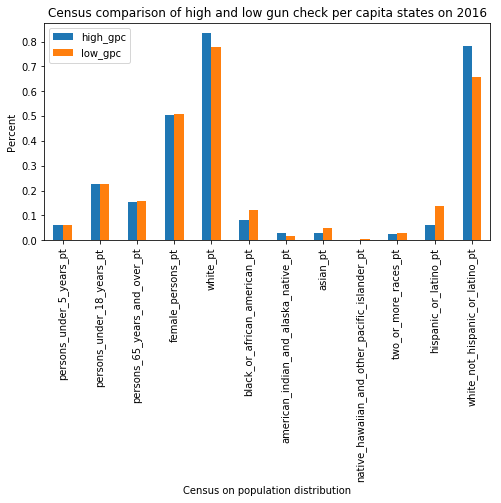

```python
df_pt_mean.plot(kind='bar',figsize=(8,4));
plt.xlabel('Census on population distribution')
plt.ylabel('Percent')
plt.title('Census comparison of high and low gun check per capita states on 2016')
```

Obviously, white/white_not_hispanic_or_latino percent are higher in states of high_gpc. Black_or_afican_american/hispanic_or_latino/asian percent have opposite features.

```python
df1 = df_2016.drop(df_high[df_high['state']=='Kentucky'].index)
```

Drop the 'Kentucky' data in scatterplots.

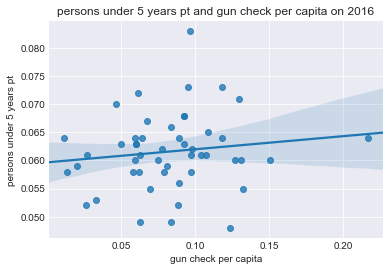

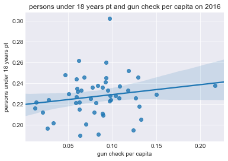

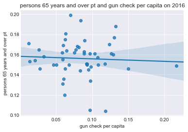

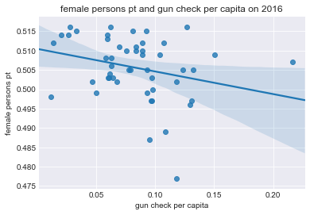

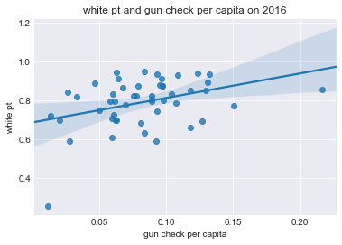

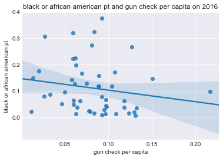

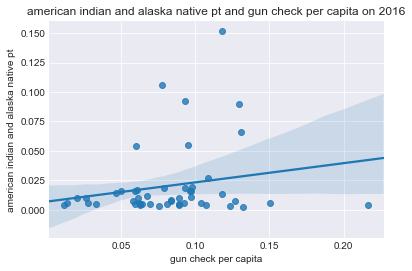

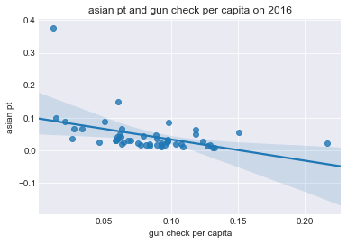

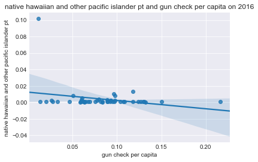

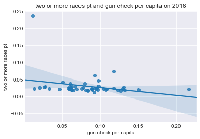

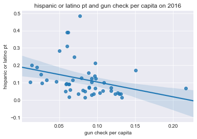

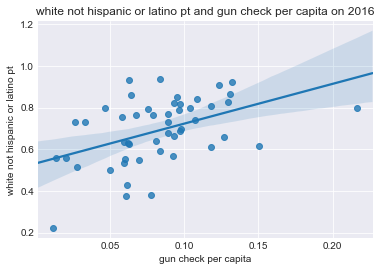

[2 more figures not shown]

```python
for c in df1.columns[3:-1]:
    plt.figure()
    sns.set_style('darkgrid')
    ax = sns.regplot(x='gun_per_cap', y=c, data=df1.loc[:,['gun_per_cap',c]])
    ax.set_title(c.replace('_',' ') + ' and gun check per capita on 2016')
    plt.xlabel('gun check per capita')
    plt.ylabel(c.replace('_',' '))
```

We can observe from the scatterplots and linea regression models that: although female_pt, white_pt, black_or_african_american_pt, asian_pt, hispanic_or_latino_pt, white_not_hispanic_or_latino_pt etc. show obviouse correlations with the gun check capita, the most associate census data are white_pt and white_not_hispanic_or_latino_pt. Thus, it seems states with higer white percentage will have higher gun check per capita.

### Which states have had the highest growth in gun check?

To study which states have had the highest growth in gun checks, we need the gun check data groupby state and year, which is a littel different from df_gun_year_state created in solving the first question. Line charts are used to illustrate the annual gun check totals of states, and can give intuitive conclusions.Then, the average growth rates are calculated and compared.

```python
df2 = df_gun_year_state.unstack(level=0)
df2.head(3)
```

| year state | 1998 | 1999 | 2000 | 2001 | 2002 | 2003 | 2004 | 2005 | 2006 | 2007 | 2008 | 2009 | 2010 | 2011 | 2012 | 2013 | 2014 | 2015 | 2016 | 2017 |
| --- | --- | --- | --- | --- | --- | --- | --- | --- | --- | --- | --- | --- | --- | --- | --- | --- | --- | --- | --- | --- |
| Alabama | 36568 | 246756 | 221911 | 230187 | 221008 | 225479 | 229997 | 235873 | 243176 | 245355 | 299432 | 317868 | 308607 | 336102 | 431356 | 563880 | 621305 | 737509 | 616947 | 336763 |
| Alaska | 3985 | 43073 | 39959 | 39959 | 36793 | 37059 | 40504 | 44514 | 47037 | 49604 | 61729 | 60780 | 65909 | 70198 | 85342 | 93405 | 87623 | 85621 | 87647 | 56902 |
| Arizona | 17453 | 173548 | 148263 | 147582 | 142260 | 145719 | 155719 | 176649 | 204178 | 192071 | 208721 | 215379 | 206050 | 251477 | 339663 | 363036 | 310672 | 331442 | 416279 | 279553 |

Pivot the df_gun_year_state to get annual gun check data for each state.

```python
maxn = 15
df3 = df2.nlargest(maxn,'2016')
topstates = df3.index
topstates
```

```
Index(['Kentucky', 'California', 'Illinois', 'Texas', 'Indiana', 'Florida',
       'Pennsylvania', 'Ohio', 'Tennessee', 'Washington', 'Minnesota',
       'Missouri', 'Alabama', 'Georgia', 'North Carolina'],
      dtype='object', name='state')
```

Choose the largest states by total gun checks in year 2016. This is for the conciseness of legend in the following line charts.

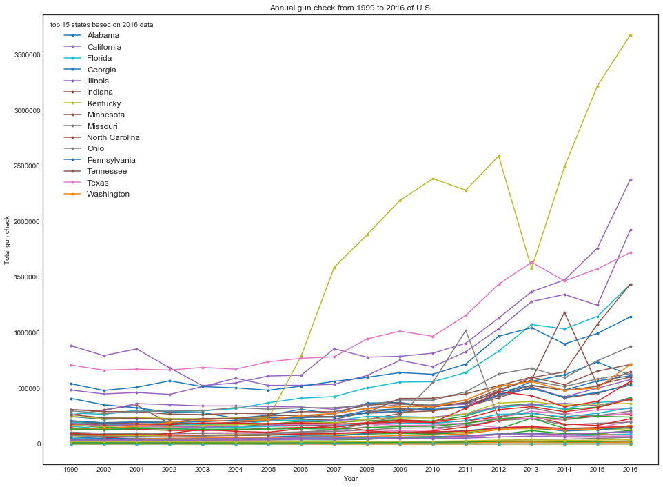

```python
plt.figure(figsize=(16,12))
sns.set_style('white')
plt.title('Annual gun check from 1999 to 2016 of U.S.')
plt.xlabel('Year')
plt.ylabel('Total gun check')
for i in df2.index:
    plt.plot(df2.columns[1:-1],df2.loc[i,df2.columns[1:-1]],marker='.',label = (i not in topstates)*"_"+str(i));
plt.legend(title="top 15 states based on 2016 data", fontsize='large')
plt.show()
```

Data of year 1998 and 2017 are not complete, so they are dropped when ploting the line charts.It can be observed that Kentucky,California, Illinois, Texas, Indiana etc. grow very fast and have high gun checks compared to other states.

```python
df4 = df_gun_year_state.unstack(level=1)
df4.drop(['1998','2017'],inplace=True)
```

Pivot df_gun_year_state and drop data of year 1998 and 2017 to further compute the average anaul growth rate for each state.

```python
growthrate = df4.pct_change().mean().sort_values(ascending=False)
growthrate
```

```
state
Mariana Islands              inf
Virgin Islands               inf
District of Columbia    0.825320
Kentucky                0.264789
Massachusetts           0.187633
Guam                    0.187510
Utah                    0.174970
Indiana                 0.136106
Washington              0.111024
Florida                 0.106079
New Hampshire           0.096334
Illinois                0.095510
Wisconsin               0.088810
Connecticut             0.086821
New Jersey              0.086039
Minnesota               0.083923
Delaware                0.081573
South Dakota            0.081027
Puerto Rico             0.080250
North Carolina          0.079392
Hawaii                  0.078569
California              0.073299
Missouri                0.072134
Ohio                    0.071634
South Carolina          0.069399
Tennessee               0.068280
Rhode Island            0.067728
Colorado                0.063476
Alabama                 0.062379
Nevada                  0.061751
Virginia                0.061374
Arizona                 0.060667
North Dakota            0.059807
Iowa                    0.058241
Maryland                0.057820
Texas                   0.057644
Maine                   0.056001
New York                0.051530
Pennsylvania            0.050942
Oklahoma                0.050433
Oregon                  0.047049
Louisiana               0.046559
Alaska                  0.046268
Idaho                   0.044215
Michigan                0.043429
Nebraska                0.043058
Kansas                  0.042935
Montana                 0.039490
West Virginia           0.038494
Vermont                 0.038446
Wyoming                 0.038034
New Mexico              0.035302
Georgia                 0.035230
Mississippi             0.028130
Arkansas                0.025816
dtype: float64
```

growthrate is the sorted series of average annual growth rate of states.

```python
df4.loc[:,growthrate.index[:3]]
```

| state year | Mariana Islands | Virgin Islands | District of Columbia |
| --- | --- | --- | --- |
| 1999 | 51 | 0 | 21 |
| 2000 | 13 | 0 | 17 |
| 2001 | 148 | 0 | 17 |
| 2002 | 35 | 1 | 7 |
| 2003 | 6 | 0 | 11 |
| 2004 | 0 | 0 | 14 |
| 2005 | 0 | 40 | 20 |
| 2006 | 26 | 1203 | 252 |
| 2007 | 11 | 1461 | 136 |
| 2008 | 0 | 1536 | 259 |
| 2009 | 0 | 1759 | 369 |
| 2010 | 0 | 1594 | 349 |
| 2011 | 1 | 1356 | 300 |
| 2012 | 5 | 399 | 449 |
| 2013 | 13 | 1134 | 497 |
| 2014 | 12 | 1271 | 512 |
| 2015 | 18 | 1342 | 742 |
| 2016 | 17 | 1087 | 875 |

The sorted growthrate series shows that data of Mariana Islands, Virgin Islands, and District of Columbia are outliers. By digging into the original data, we can see that the three states have either number 0 or very few number. They are not very valueable to study the proposed question, and are ignored.

In the remaining states, Kentucky, Massachusetts, Guam, Utah, Indiana, Washington and Florida have average growth rate over 10%.

```python
growthrate[topstates].sort_values(ascending=False)
```

```
state
Kentucky          0.264789
Indiana           0.136106
Washington        0.111024
Florida           0.106079
Illinois          0.095510
Minnesota         0.083923
North Carolina    0.079392
California        0.073299
Missouri          0.072134
Ohio              0.071634
Tennessee         0.068280
Alabama           0.062379
Texas             0.057644
Pennsylvania      0.050942
Georgia           0.035230
dtype: float64
```

Considering the total gun check number, Kentucky, Indiana, Washington and Florida have both highest gun checks and growth rate.

### What is the overall trend of gun checks?

To analyze the overall trend of gun checks, the df_gun dataframe will be groupby 'year' to get anual gun check data.Scatterplot and regression model are applied to illustrate the overall trend of gun checks, and can be used to forecast the futrue gun checks.

```python
df_gun_year = df_gun.groupby('year')['totals'].sum()[1:-1].to_frame()
df_gun_year.reset_index(level=0, inplace=True)
df_gun_year['year'] = df_gun_year['year'].astype(int)
```

To convert 'year' column to int is for convinence in the following regression model.

```
(1997, 2018)
```

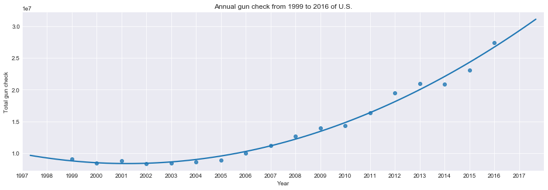

```python
sns.set_style('darkgrid')
plt.figure(figsize=(16,5))
sns.regplot(x='year', y='totals', data=df_gun_year,ci=None,order = 2);
plt.title('Annual gun check from 1999 to 2016 of U.S.')
plt.xlabel('Year')
plt.ylabel('Total gun check')
plt.xticks(range(1997,2018));
plt.xlim([1997,2018])
```

The scatterplot shows an accelerated increase of annual gun checks, which represents that purchase of gun increases over time. The regression model is a second order (order = 2) polynomial form. It fits the true data points very well.

## Conclusions

In this project, the investigation are based on NICS firearm background checks with FBI gun data and census data. Although the analysis is tentative, we can have a comprehensive insight on the gun activities in the U.S., and also have some interesting findings as follow.

**States of high gun check per capita has higer white people percentage.**

Based on the comparison on states of high/low gun check per capita, white people percentage are higher in states of high_gpc, black, hispanic, and asian people percent are higher in states of low_gpc. Also, the states of lower gun check per capita have larger housing units and building permits.

The scatterplots and linear regression models of census data and gun check per capita show the most positive associate census data are white people percentage. Thus, it seems states with higer white percentage will have higher gun check per capita. The other census data such as female, black, asian, hispanic etc. show weak negative correlations with the gun check capita.

There are several things need to be noted of the first question. 1) The analysis does not state or imply that one change causes another based solely on a correlation. The gun activities are influenced by many aspects. Although census association analysis in this project can get some insights of this problem, comprehensive and deeper analysis should consider more. 2) Scatterplots and regression models in DEA can provide intuitive illustration of the correlations of census data and gun check per capita. However, the correlation coefficient and statistical tests are essential for more reliable conclusions. 3) During the investigation, only data of year 2016 are studied due to the census data limitation. With more data from different years, we can conduct more analysis and may get consistent conclusions.

**Kentucky has both high gun checks and growth rate**

Despite of the truth that Kentucky has both high gun checks and growth rate, there are more information can be further analyzed from the line charts, such as big increase in year 2006 and sharp drop in 2013.There must be some gun related laws, policies or events behind the data.

As noted in the Indrodution, since 1998 November, NICS is used to determine whether a prospective buyer is eligible to buy firearms or explosives. Then the gun checks shows an acccelerated increase, which indicates the increased demand of gun related activities.

Obviously, the regplot gives a very fit second order polynomial form of the gun check trends. For more reliable results, statistical analysis such as r-sq, analysis of variance, residual analysis are quite important. What's more, the third question in this project only dipict the history of gun actvities, predictions on the future can be conduct for future study such as the estimate of gun checks in year 2017 (and we do have 9 months data for 2017!).